# HeartDieasePrediction

Yunsheng Li & Yung-Lin Chang

November 21, 2017

### Introduction

Our project is mainly focused on the heart disease prediction by using the machine learning algorithm to explore whether the patient have heart disease or not. In the process of finding the meaningful model, we have done the data exploration, data preparation, model comparison and feature selection. After evaluating the effectiveness of all the options, we concluded the random forest model with all 14 features has the best performance in this prediction.

### Data Source and Method

The data was retrieved from UCI Machine Learning Repository http://archive.ics.uci.edu/ml/datasets/heart+Disease. Based on the dataset, the supervised learning algorithm and binary classification method was used to explore and generate the prediction model by R and R packages.

### The dataset

The dataset has 303 observations and 14 attributes which the 14th attribute “status” is the predictable attribute showing either absence or presence of the heart disease on the patient.

```r
hd <- read.table("heart.disease.txt", header = FALSE, sep = ",")
colnames(hd) <- c("age", "sex", "cp", "trestbps", "chol", "fbs", "restecg", "thalach", "exang", "oldpeak", "slope", "ca", "thal", "status")
## sex: (1 = male; 0 = female)
## cp: chest pain type:
##       Value 1: typical angina
##       Value 2: atypical angina
##       Value 3: non-anginal pain
##       Value 4: asymptomatic
## trsetbps: resting blood pressure (mmHg)
## chol: serum cholesterol in mg/dl
## fbs: fasting blood sugar > 120 mg/dl (1 = true; 0 = false)
## restecg: resting electrocardiographic results:
##       Value 0: normal
##       Value 1: having ST-T wave abnormality (T wave inversions and/or ST elevation or depression of > 0.05 mV)
##       Value 2: showing probable or definite left ventricular hypertrophy by Estes' criteria
## thalach: maximum heart rate achieved
## exang: exercise induced angina (1 = yes; 0 = no)
## oldpeak: ST depression induced by exercise relative to rest
## slope: the slope of the peak exercise ST segment
##       Value 1: upsloping
##       Value 2: flat
##       Value 3: downsloping
## ca: number of major vessels (0-3) colored by fluoroscopy
## thal: 3 = normal; 6 = fixed defect; 7 = reversible defect
## status: diagnosis of heart disease
##       Value < 0: < 50% diameter narrowing (Absence)
##       Value > 0: > 50% diameter narrowing (Presence)
```

### Data Preparation

#### /Missing Data/

- Packages used: **mice** (missing data imputation), **VIM** (missing data visulization)

We first turned missing values “?” into NA. 6 missing values were found in the dataset which located in attribute ca and thal as the shown graph generated by package VIM. We impute the missing data by mice package in the method of ‘cart’, which imputes univariate missing data using classification and regression trees.

```r
##turn missing value into NA
hd[hd == "?"] <- NA

## check the missing data pattern: only ca and thal have NA
library(mice)
md.pattern(hd)
```

```
##     age sex cp trestbps chol fbs restecg thalach exang oldpeak slope
## 297   1   1  1        1    1   1       1       1     1       1     1
##   4   1   1  1        1    1   1       1       1     1       1     1
##   2   1   1  1        1    1   1       1       1     1       1     1
##       0   0  0        0    0   0       0       0     0       0     0
##     status thal ca
## 297      1    1  1 0
##   4      1    1  0 1
##   2      1    0  1 1
##          0    2  4 6
```

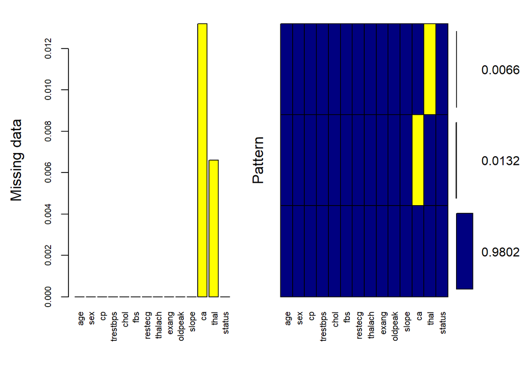

```r
library(VIM)
aggr(hd, col=c('navyblue','yellow'), numbers=TRUE,
      labels=names(hd), cex.axis=.7, gap=3,
      ylab=c("Missing data","Pattern"))
```

```r
## impute missing data
imputed <- mice(hd, m=5, meth = 'cart',seed = 500)
##check the imputed data
imputed$imp$ca
```

```
##       1   2   3   4   5
## 167 0.0 3.0 0.0 0.0 3.0
## 193 0.0 0.0 0.0 0.0 0.0
## 288 0.0 0.0 0.0 0.0 0.0
## 303 0.0 0.0 0.0 0.0 0.0
```

```r
imputed$imp$thal
```

```
##       1   2   3   4   5
## 88  3.0 3.0 3.0 3.0 3.0
## 267 7.0 7.0 7.0 6.0 6.0
```

```r
## complete dataset
new_hd <- complete(imputed, 1)
new_hd$ca <- as.numeric(as.character(new_hd$ca))
new_hd$thal <- as.numeric(as.character(new_hd$thal))
summary(new_hd)
```

```
##       age             sex               cp           trestbps
##  Min.   :29.00   Min.   :0.0000   Min.   :1.000   Min.   : 94.0
##  1st Qu.:48.00   1st Qu.:0.0000   1st Qu.:3.000   1st Qu.:120.0
##  Median :56.00   Median :1.0000   Median :3.000   Median :130.0
##  Mean   :54.44   Mean   :0.6799   Mean   :3.158   Mean   :131.7
##  3rd Qu.:61.00   3rd Qu.:1.0000   3rd Qu.:4.000   3rd Qu.:140.0
##  Max.   :77.00   Max.   :1.0000   Max.   :4.000   Max.   :200.0
##       chol            fbs            restecg          thalach
##  Min.   :126.0   Min.   :0.0000   Min.   :0.0000   Min.   : 71.0
##  1st Qu.:211.0   1st Qu.:0.0000   1st Qu.:0.0000   1st Qu.:133.5
##  Median :241.0   Median :0.0000   Median :1.0000   Median :153.0
##  Mean   :246.7   Mean   :0.1485   Mean   :0.9901   Mean   :149.6
##  3rd Qu.:275.0   3rd Qu.:0.0000   3rd Qu.:2.0000   3rd Qu.:166.0
##  Max.   :564.0   Max.   :1.0000   Max.   :2.0000   Max.   :202.0
##      exang           oldpeak         slope             ca
##  Min.   :0.0000   Min.   :0.00   Min.   :1.000   Min.   :0.0000
##  1st Qu.:0.0000   1st Qu.:0.00   1st Qu.:1.000   1st Qu.:0.0000
##  Median :0.0000   Median :0.80   Median :2.000   Median :0.0000
##  Mean   :0.3267   Mean   :1.04   Mean   :1.601   Mean   :0.6634
##  3rd Qu.:1.0000   3rd Qu.:1.60   3rd Qu.:2.000   3rd Qu.:1.0000
##  Max.   :1.0000   Max.   :6.20   Max.   :3.000   Max.   :3.0000
##       thal           status
##  Min.   :3.000   Min.   :0.0000
##  1st Qu.:3.000   1st Qu.:0.0000
##  Median :3.000   Median :0.0000
##  Mean   :4.736   Mean   :0.9373
##  3rd Qu.:7.000   3rd Qu.:2.0000
##  Max.   :7.000   Max.   :4.0000
```

```r
nrow(new_hd[is.na(new_hd), ])
```

```
## [1] 0
```

```r
head(new_hd)
```

```
##   age sex cp trestbps chol fbs restecg thalach exang oldpeak slope ca thal
## 1  63   1  1      145  233   1       2     150     0     2.3     3  0    6
## 2  67   1  4      160  286   0       2     108     1     1.5     2  3    3
## 3  67   1  4      120  229   0       2     129     1     2.6     2  2    7
## 4  37   1  3      130  250   0       0     187     0     3.5     3  0    3
## 5  41   0  2      130  204   0       2     172     0     1.4     1  0    3
## 6  56   1  2      120  236   0       0     178     0     0.8     1  0    3
##   status
## 1      0
## 2      2
## 3      1
## 4      0
## 5      0
## 6      0
```

#### /Scale the feature/

- Packages used: **ggplot2** (powerful plotting package), **magrittr** (%>%, decrease development time and to improve readability and maintainability of code), **tidyr** (for gather() Function)

Scale the data by the method of Z-Score normalization (data pre-processing). Density plots were representing how data distributed and the relationship between status and each features.

```r
new_hd2 <- new_hd
new_hd2$status <- ifelse(new_hd2$status == 0, "absence", "presence")
new_hd2$status <- as.factor(new_hd2$status)
new_hd2[,-14] <- scale(new_hd2[,-14],center = TRUE, scale = TRUE)[,]
head(new_hd2)
```

```
##          age        sex         cp    trestbps        chol        fbs
## 1  0.9471596  0.6850692 -2.2480557  0.75627397 -0.26446281  2.3904835
## 2  1.3897030  0.6850692  0.8765355  1.60855891  0.75915934 -0.4169448
## 3  1.3897030  0.6850692  0.8765355 -0.66420094 -0.34171732 -0.4169448
## 4 -1.9293722  0.6850692 -0.1649949 -0.09601098  0.06386882 -0.4169448
## 5 -1.4868288 -1.4548891 -1.2065253 -0.09601098 -0.82455796 -0.4169448
## 6  0.1727088  0.6850692 -1.2065253 -0.66420094 -0.20652194 -0.4169448
##      restecg     thalach    exang    oldpeak      slope         ca
## 1  1.0150052  0.01716893 -0.69548  1.0855423  2.2708221 -0.7099569
## 2  1.0150052 -1.81889638  1.43311  0.3965257  0.6480412  2.5007438
## 3  1.0150052 -0.90086373  1.43311  1.3439235  0.6480412  1.4305102
## 4 -0.9951031  1.63465503 -0.69548  2.1190672  2.2708221 -0.7099569
## 5  1.0150052  0.97891742 -0.69548  0.3103986 -0.9747397 -0.7099569
## 6 -0.9951031  1.24121247 -0.69548 -0.2063639 -0.9747397 -0.7099569
##         thal   status
## 1  0.6514824  absence
## 2 -0.8947252 presence
## 3  1.1668850 presence
## 4 -0.8947252  absence
## 5 -0.8947252  absence
## 6 -0.8947252  absence
```

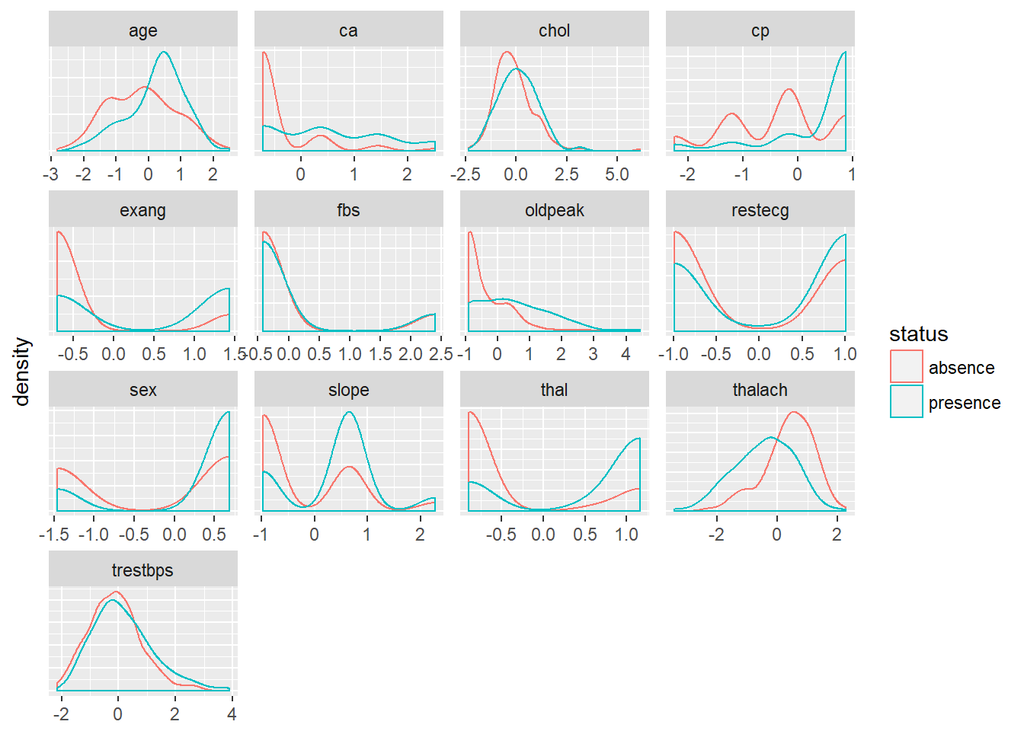

```r
library(ggplot2)
library(magrittr)
library(tidyr)

gather(new_hd2, x, y, age:thal) %>%
  ggplot(aes(x = y, color = status, group=status)) +
    geom_density() +
    facet_wrap( ~ x, scales = "free", ncol = 4) +
    theme(axis.title.x =element_blank(),
        axis.text.y =element_blank(),
        axis.ticks.y=element_blank())
```

#### /Categorical variables/

- Packages used: **ggplot2** (powerful plotting package), **magrittr** (%>%, decrease development time and to improve readability and maintainability of code), **tidyr** (for gather() Function)

9 attributes are categorical variable. We transformed the attributes as factor with labels based on the data description. Density plots were shown in two sections: continuous variables and categorical variables representing how data distributed and the relationship between status and each features. The peaks of a Density Plot help display where values are concentrated over the interval. An advantage Density Plots have over Histograms is that they’re better at determining the distribution shape because they’re not affected by the number of bins used. The pattern of the graphs are identical to the scaled data, but the only difference is the factored data will show the labels of the data on the graphs not just numbers.

```r
new_hd3 <- new_hd
new_hd3$sex <- factor(new_hd3$sex, labels = c("female", "male"))
new_hd3$cp <- factor(new_hd3$cp, labels = c("typical", "atypical", "non-anginal", "asymptomatic"))
new_hd3$fbs <- factor(new_hd3$fbs, labels = c("False", "True"))
new_hd3$restecg <- factor(new_hd3$restecg, labels = c("normal", "abnorm", "hyper"))
new_hd3$exang <- factor(new_hd3$exang, labels = c("no", "yes"))
new_hd3$slope <- factor(new_hd3$slope, labels = c("up", "flat", "down"))
new_hd3$ca <- as.factor(new_hd3$ca)
new_hd3$thal <- factor(new_hd3$thal, labels = c("norm", "fix", "rev"))
## status: "absenece" == 0, "presence" == 1-4
new_hd3$status <- ifelse(new_hd3$status == 0, "absence", "presence")
new_hd3$status <- as.factor(new_hd3$status)
str(new_hd3)
```

```
## 'data.frame':    303 obs. of  14 variables:
##  $ age     : num  63 67 67 37 41 56 62 57 63 53 ...
##  $ sex     : Factor w/ 2 levels "female","male": 2 2 2 2 1 2 1 1 2 2 ...
##  $ cp      : Factor w/ 4 levels "typical","atypical",..: 1 4 4 3 2 2 4 4 4 4 ...
##  $ trestbps: num  145 160 120 130 130 120 140 120 130 140 ...
##  $ chol    : num  233 286 229 250 204 236 268 354 254 203 ...
##  $ fbs     : Factor w/ 2 levels "False","True": 2 1 1 1 1 1 1 1 1 2 ...
##  $ restecg : Factor w/ 3 levels "normal","abnorm",..: 3 3 3 1 3 1 3 1 3 3 ...
##  $ thalach : num  150 108 129 187 172 178 160 163 147 155 ...
##  $ exang   : Factor w/ 2 levels "no","yes": 1 2 2 1 1 1 1 2 1 2 ...
##  $ oldpeak : num  2.3 1.5 2.6 3.5 1.4 0.8 3.6 0.6 1.4 3.1 ...
##  $ slope   : Factor w/ 3 levels "up","flat","down": 3 2 2 3 1 1 3 1 2 3 ...
##  $ ca      : Factor w/ 4 levels "0","1","2","3": 1 4 3 1 1 1 3 1 2 1 ...
##  $ thal    : Factor w/ 3 levels "norm","fix","rev": 2 1 3 1 1 1 1 1 3 3 ...
##  $ status  : Factor w/ 2 levels "absence","presence": 1 2 2 1 1 1 2 1 2 2 ...
```

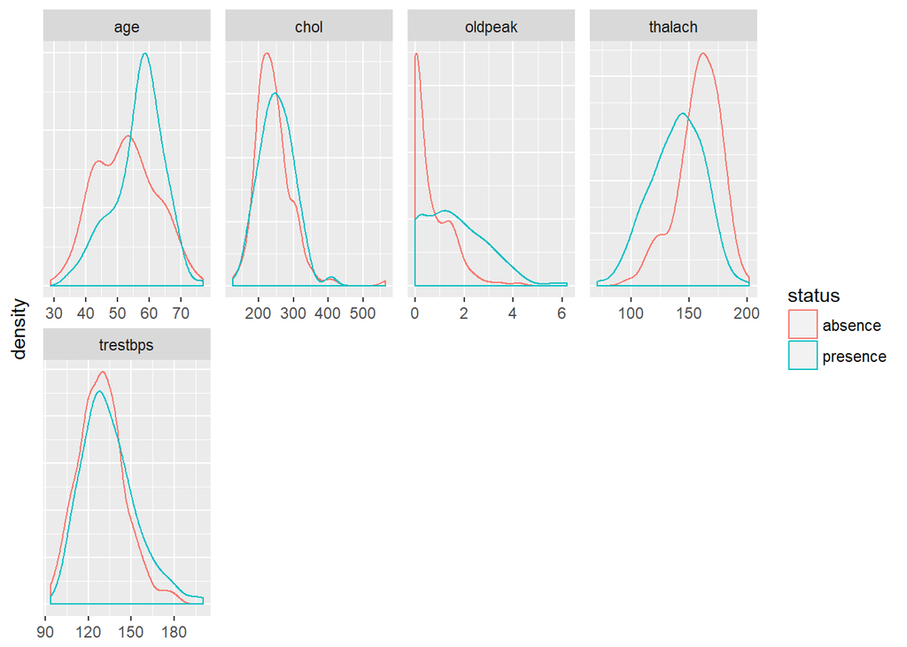

```r
# continuous variables
gather(new_hd3, x, y, c(age, chol, oldpeak, thalach, trestbps)) %>%
  ggplot(aes(x = y, color = status, group=status)) +
    geom_density() +
    facet_wrap( ~ x, scales = "free", ncol = 4) +
    theme(axis.title.x =element_blank(),
        axis.text.y =element_blank(),
        axis.ticks.y=element_blank())
```

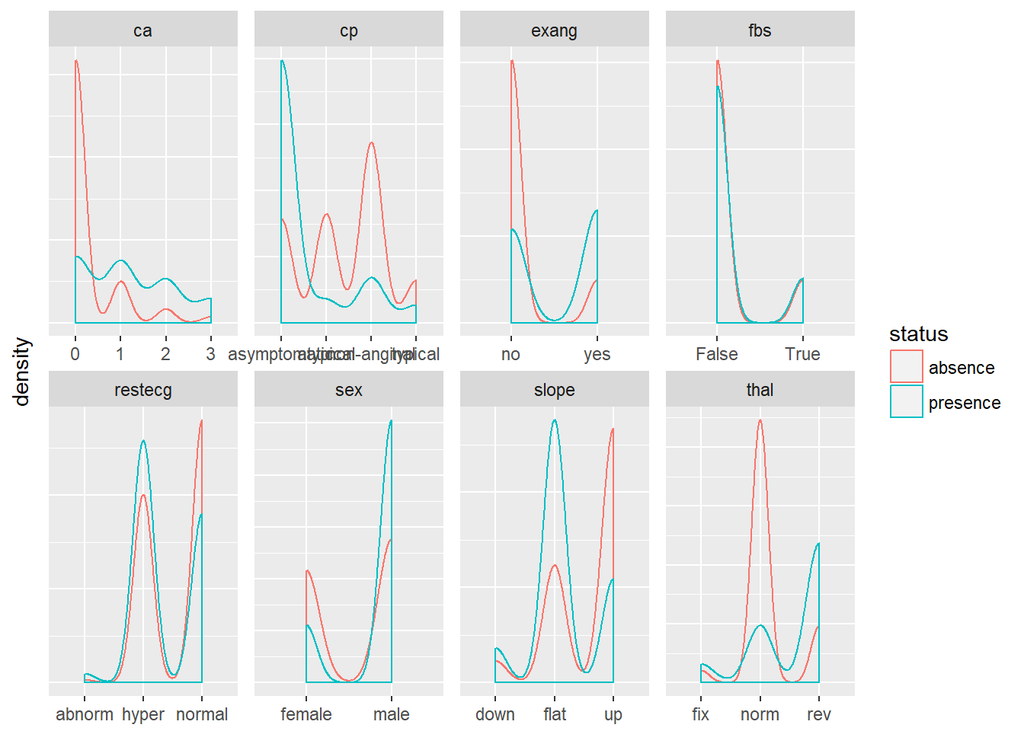

```r
# categorical variables
gather(new_hd3, x, y, c(sex, ca, cp, exang, fbs, restecg, slope, thal)) %>%
  ggplot(aes(x = y, color = status, group=status)) +
    geom_density() +
    facet_wrap( ~ x, scales = "free", ncol = 4) +
    theme(axis.title.x =element_blank(),
        axis.text.y =element_blank(),
        axis.ticks.y=element_blank())
```

### Data Exploration

#### /imbalanced response variable/

- Packages used: **ggplot2** (powerful plotting package)

Most machine learning classification algorithm are sensitive to imbalance in the predictor classes. We have imbalanced data in the response variable. ROSE (Random Over-Sampling Examples) package will be used to provide functions to deal with binary classification problems in the presence of imbalanced classes.

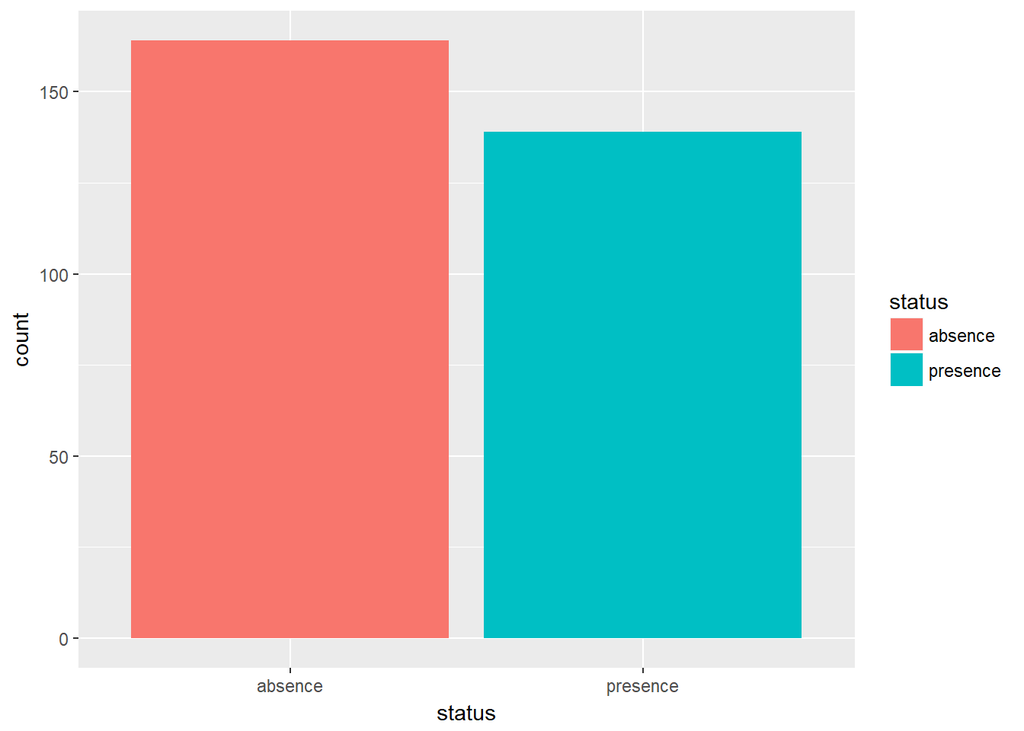

```r
ggplot(new_hd3, aes(x = status, fill = status)) + geom_bar()
```

#### /Features/

- Packages used: **ggplot2** (powerful plotting package)

Categorical variable and continuous variable are both in the dataset. Feature “thal” was shown as a categorical variable and feature “chol” was shown as a continuous variable.

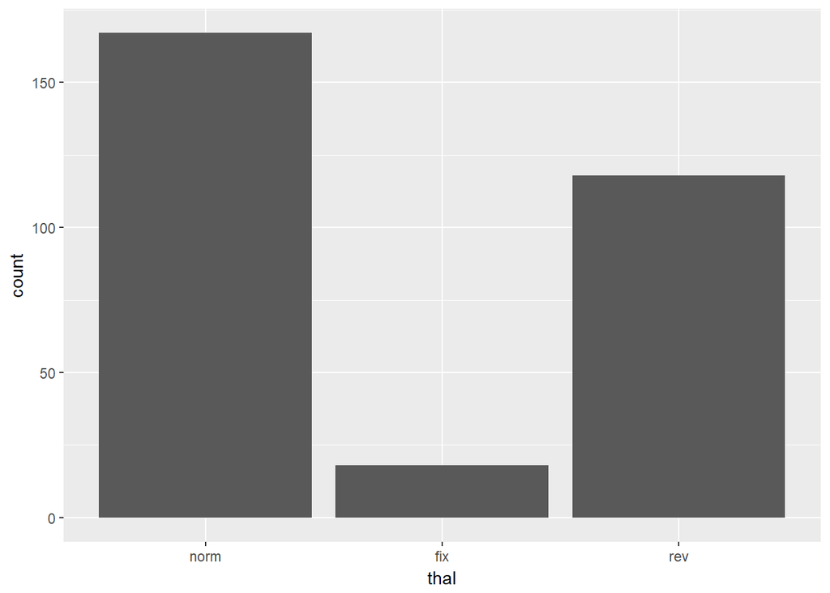

```r
## thal variable
ggplot(new_hd3, aes(x = thal)) + geom_bar()
```

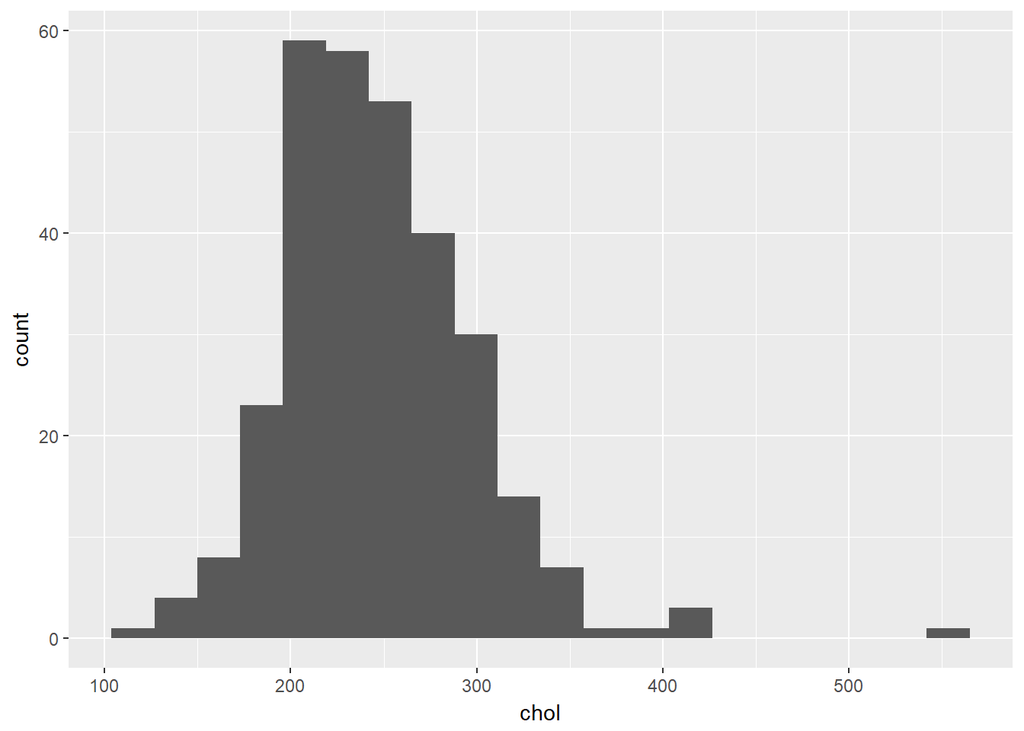

```r
## chol variable
ggplot(new_hd3, aes(x = chol)) + geom_histogram(bins = 20)
```

#### /Principal Component Analysis/

- Packages used: **pcaGoPromoter** (principal component analysis), **ellipse** (drawing ellipses and ellipse-like confidence), **ggplot2** (powerful plotting package)

One benefit of Principal component analysis(PCA) is that we can examine the variances associated with the principle components. Normally the first principal component has the largest possible variance, and each succedding component in turn has the highest variance possible under the constraint that it is orthogonal to the preceding components. Here the 1st and 2nd component both have low variance, meaning that each dimensions are more equally important to the target data.So we can’t just throw out the less important axes for dimensional reduction purpose.

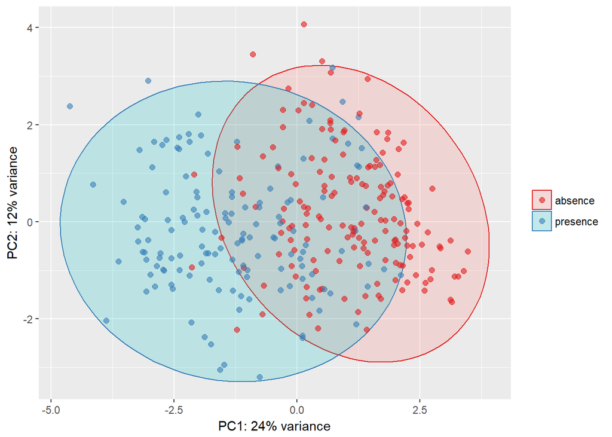

```r
#setRepositories(ind = c(1:6, 8))
library(pcaGoPromoter)
library(ellipse)

# perform pca and extract scores
pcaOutput <- pca(t(new_hd2[, -14]), printDropped = FALSE, scale = TRUE, center = TRUE)
pcaOutput2 <- as.data.frame(pcaOutput$scores)

# define groups for plotting
pcaOutput2$groups <- new_hd2$status

centroids <- aggregate(cbind(PC1, PC2) ~ groups, pcaOutput2, mean)

conf.rgn  <- do.call(rbind, lapply(unique(pcaOutput2$groups), function(t)
  data.frame(groups = as.character(t),
             ellipse(cov(pcaOutput2[pcaOutput2$groups == t, 1:2]),
                   centre = as.matrix(centroids[centroids$groups == t, 2:3]),
                   level = 0.95),
             stringsAsFactors = FALSE)))

ggplot(data = pcaOutput2, aes(x = PC1, y = PC2, group = groups, color = groups)) +
    geom_polygon(data = conf.rgn, aes(fill = groups), alpha = 0.2) +
    geom_point(size = 2, alpha = 0.6) +
    scale_color_brewer(palette = "Set1") +
    labs(color = "",
         fill = "",
         x = paste0("PC1: ", round(pcaOutput$pov[1], digits = 2) * 100, "% variance"),
         y = paste0("PC2: ", round(pcaOutput$pov[2], digits = 2) * 100, "% variance"))
```

#### /Correlation/

- Packages used: **corrplot** (correlation visulization)

Correlations between all features are calculated and visualized with the corrplot package. The highest cofficient is about only 0.6, which came from the slope column, meanning the correlations among each feature are not so high.We should be very careful, When we deduct the feature.

```r
library(corrplot)
corr_numeric <- cor(new_hd2[,-14])
corr_numeric
```

```
##                  age         sex          cp    trestbps         chol
## age       1.00000000 -0.09754228  0.10413895  0.28494592  0.208950270
## sex      -0.09754228  1.00000000  0.01008389 -0.06445590 -0.199914683
## cp        0.10413895  0.01008389  1.00000000 -0.03607725  0.072318884
## trestbps  0.28494592 -0.06445590 -0.03607725  1.00000000  0.130120108
## chol      0.20895027 -0.19991468  0.07231888  0.13012011  1.000000000
## fbs       0.11853024  0.04786212 -0.03997499  0.17534023  0.009841023
## restecg   0.14886759  0.02164735  0.06750523  0.14656039  0.171042532
## thalach  -0.39380581 -0.04866330 -0.33442171 -0.04535088 -0.003431832
## exang     0.09166077  0.14620149  0.38405953  0.06476246  0.061310377
## oldpeak   0.20380548  0.10217264  0.20227654  0.18917097  0.046563989
## slope     0.16176956  0.03753288  0.15205042  0.11738158 -0.004061834
## ca        0.36532320  0.08604788  0.23311746  0.09752821  0.123725761
## thal      0.12633874  0.38489478  0.26782294  0.13286521  0.012704760
##                   fbs     restecg      thalach       exang      oldpeak
## age       0.118530242  0.14886759 -0.393805806  0.09166077  0.203805481
## sex       0.047862121  0.02164735 -0.048663296  0.14620149  0.102172644
## cp       -0.039974990  0.06750523 -0.334421706  0.38405953  0.202276541
## trestbps  0.175340227  0.14656039 -0.045350879  0.06476246  0.189170971
## chol      0.009841023  0.17104253 -0.003431832  0.06131038  0.046563989
## fbs       1.000000000  0.06956450 -0.007854147  0.02566515  0.005747223
## restecg   0.069564497  1.00000000 -0.083389433  0.08486695  0.114132813
## thalach  -0.007854147 -0.08338943  1.000000000 -0.37810342 -0.343085392
## exang     0.025665147  0.08486695 -0.378103424  1.00000000  0.288222808
## oldpeak   0.005747223  0.11413281 -0.343085392  0.28822281  1.000000000
## slope     0.059894178  0.13394569 -0.385601162  0.25774837  0.577536817
## ca        0.140763859  0.13174877 -0.265698826  0.14578813  0.301066664
## thal      0.080881892  0.01750920 -0.271973082  0.33471363  0.341845515
##                 slope          ca        thal
## age       0.161769559  0.36532320  0.12633874
## sex       0.037532882  0.08604788  0.38489478
## cp        0.152050417  0.23311746  0.26782294
## trestbps  0.117381584  0.09752821  0.13286521
## chol     -0.004061834  0.12372576  0.01270476
## fbs       0.059894178  0.14076386  0.08088189
## restecg   0.133945690  0.13174877  0.01750920
## thalach  -0.385601162 -0.26569883 -0.27197308
## exang     0.257748369  0.14578813  0.33471363
## oldpeak   0.577536817  0.30106666  0.34184551
## slope     1.000000000  0.11080337  0.29094249
## ca        0.110803371  1.00000000  0.25035623
## thal      0.290942491  0.25035623  1.00000000
```

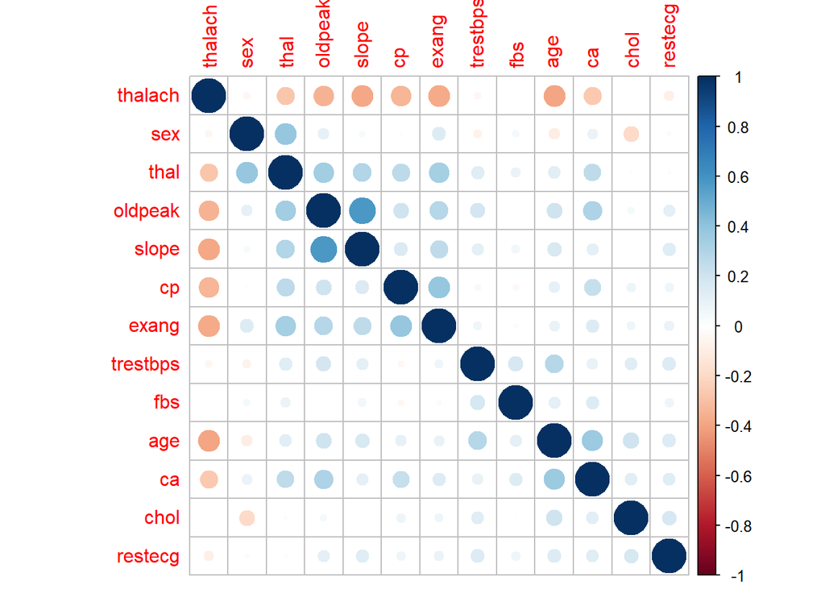

```r
corrplot(corr_numeric, order = "hclust")
```

### Data Partition

- Packages used: **caret** (for *createDataPartition()* Function), **ggplot2** (powerful plotting package), **magrittr** (*%>%*, decrease development time and to improve readability and maintainability of code), **tidyr** (for *gather()* Function)

We splited the data into training set and testing set in the ratio of 80:20. It is good to have almost the same pattern in training and testing sets acrosss all the features.

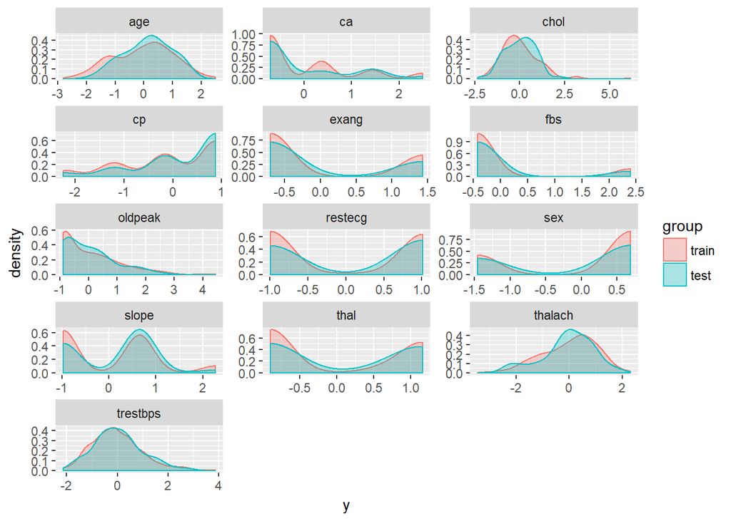

```r
library(caret)
set.seed(100)
index <- createDataPartition(new_hd2$status,p = 0.8, list=FALSE)
train_data2 <- new_hd2[index,]
test_data2 <- new_hd2[-index,]


rbind(data.frame(group = "train", train_data2),
      data.frame(group = "test", test_data2)) %>%
  gather(x,y,age:thal) %>%
  ggplot(aes(x = y, color = group, fill = group)) +
  geom_density(alpha = 0.3) +
  facet_wrap( ~ x, scales = "free", ncol = 3)
```

### Prediction Models - Tree-based Classification

#### /Desicion Tree/

- Packages used: **ROSE** (dealing with imbalance data), **rpart** (decision tree model), **rpart.plot** (decision tree model visulization), **caret**(For *ConfusionMatrix()* function), **ggplot2** (powerful plotting package)

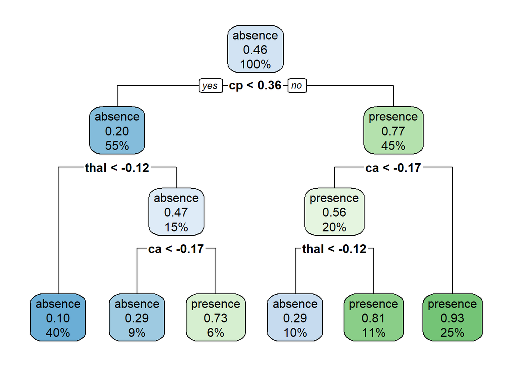

```r
library(ROSE)
library(rpart)
decision_fit <- rpart(status ~ ., data = train_data2, method = "class",
                        control = rpart.control(sampling="rose"))

library(rpart.plot)
rpart.plot(decision_fit)
```

```r
sum_decision_fit <- summary(decision_fit) # detailed summary of splits
```

```
## Call:
## rpart(formula = status ~ ., data = train_data2, method = "class",
##     control = rpart.control(sampling = "rose"))
##   n= 244
##
##           CP nsplit rel error    xerror       xstd
## 1 0.52678571      0 1.0000000 1.0000000 0.06949972
## 2 0.04464286      1 0.4732143 0.4732143 0.05750978
## 3 0.03125000      3 0.3839286 0.5357143 0.06005810
## 4 0.01000000      5 0.3214286 0.5089286 0.05901267
##
## Variable importance
##       cp     thal    exang  thalach  oldpeak       ca    slope      age
##       28       19       13       12        9        8        5        3
##      sex trestbps     chol
##        3        1        1
##
## Node number 1: 244 observations,    complexity param=0.5267857
##   predicted class=absence   expected loss=0.4590164  P(node) =1
##     class counts:   132   112
##    probabilities: 0.541 0.459
##   left son=2 (133 obs) right son=3 (111 obs)
##   Primary splits:
##       cp      < 0.3557703   to the left,  improve=38.32291, (0 missing)
##       thal    < -0.1216214  to the left,  improve=33.84504, (0 missing)
##       ca      < -0.1748401  to the left,  improve=23.99269, (0 missing)
##       exang   < 0.3688152   to the left,  improve=22.76875, (0 missing)
##       thalach < -0.09212067 to the right, improve=19.69952, (0 missing)
##   Surrogate splits:
##       exang   < 0.3688152   to the left,  agree=0.738, adj=0.423, (0 split)
##       thalach < -0.2232682  to the right, agree=0.689, adj=0.315, (0 split)
##       thal    < -0.1216214  to the left,  agree=0.689, adj=0.315, (0 split)
##       oldpeak < -0.1633004  to the left,  agree=0.635, adj=0.198, (0 split)
##       slope   < -0.1633492  to the left,  agree=0.623, adj=0.171, (0 split)
##
## Node number 2: 133 observations,    complexity param=0.03125
##   predicted class=absence   expected loss=0.2030075  P(node) =0.545082
##     class counts:   106    27
##    probabilities: 0.797 0.203
##   left son=4 (97 obs) right son=5 (36 obs)
```

[output cut: 80 more lines]

```
##
## Node number 11: 15 observations
##   predicted class=presence  expected loss=0.2666667  P(node) =0.06147541
##     class counts:     4    11
##    probabilities: 0.267 0.733
##
## Node number 12: 24 observations
##   predicted class=absence   expected loss=0.2916667  P(node) =0.09836066
##     class counts:    17     7
##    probabilities: 0.708 0.292
##
## Node number 13: 26 observations
##   predicted class=presence  expected loss=0.1923077  P(node) =0.1065574
##     class counts:     5    21
##    probabilities: 0.192 0.808
```

```r
# testing data validation
decision_pred <- predict(decision_fit, test_data2, type = "class")
confusionMatrix(decision_pred, test_data2$status, positive = "presence")
```

```
## Confusion Matrix and Statistics
##
##           Reference
## Prediction absence presence
##   absence       28        5
##   presence       4       22
##
##                Accuracy : 0.8475
##                  95% CI : (0.7301, 0.9278)
##     No Information Rate : 0.5424
##     P-Value [Acc > NIR] : 7.195e-07
##
##                   Kappa : 0.6918
##  Mcnemar's Test P-Value : 1
##
##             Sensitivity : 0.8148
##             Specificity : 0.8750
##          Pos Pred Value : 0.8462
##          Neg Pred Value : 0.8485
##              Prevalence : 0.4576
##          Detection Rate : 0.3729
##    Detection Prevalence : 0.4407
##       Balanced Accuracy : 0.8449
##
##        'Positive' Class : presence
##
```

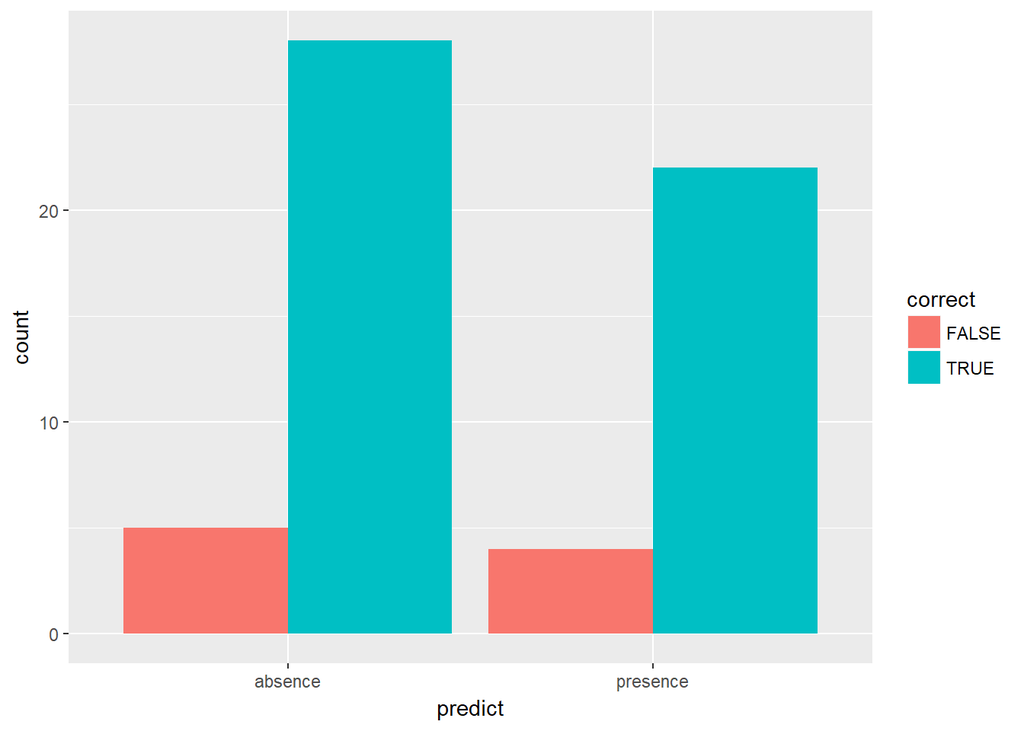

```r
# plot the predict and actural value
decision_results <- data.frame(actual = test_data2$status,
                               predict = decision_pred)
decision_results$correct <- ifelse(decision_results$actual == decision_results$predict, TRUE, FALSE)
ggplot(decision_results, aes(x = predict, fill = correct)) +
  geom_bar(position = "dodge")
```

```r
## Feature Importance
sum_decision_fit$variable.importance
```

```
##         cp       thal      exang    thalach    oldpeak         ca
## 39.4916971 27.1179228 18.4422896 16.5079020 12.2168981 11.4095093
##      slope        age        sex   trestbps       chol
##  6.5597781  4.9823718  3.6001389  1.2275073  0.9245292
```

#### /Random forest/

- Packages used: **ROSE** (dealing with imbalance data), **caret**(For rf model and *ConfusionMatrix()* function), **ggplot2** (powerful plotting package)

The second model is fandom forest. We used ROSE to take care of the imbalanced class in our model. The accuracy of the model (model_rf) is **0.8814**. We also showed the performance of the model by ConfusionMatrix and evaluating the prediction results as a histogram plot and scatter plot. Feature importance is also shown as a plot. *ca*, *oldpeak*, *cp* and *thal* have higher significance to this model.

```r
set.seed(42)
model_rf <- caret::train(status ~ .,
                         data = train_data2,
                         method = "rf",

                         trControl = trainControl(method = "repeatedcv",
                                                  number = 10,
                                                  repeats = 10,
                                                  savePredictions = TRUE,
                                                  verboseIter = FALSE,
                                                  sampling = "rose"))

# testing data validation
model_rf_pred <- predict(model_rf, test_data2)
confusionMatrix(model_rf_pred, test_data2$status, positive = "presence")
```

```
## Confusion Matrix and Statistics
##
##           Reference
## Prediction absence presence
##   absence       31        6
##   presence       1       21
##
##                Accuracy : 0.8814
##                  95% CI : (0.7707, 0.9509)
##     No Information Rate : 0.5424
##     P-Value [Acc > NIR] : 2.581e-08
##
##                   Kappa : 0.7575
##  Mcnemar's Test P-Value : 0.1306
##
##             Sensitivity : 0.7778
##             Specificity : 0.9688
##          Pos Pred Value : 0.9545
##          Neg Pred Value : 0.8378
##              Prevalence : 0.4576
##          Detection Rate : 0.3559
##    Detection Prevalence : 0.3729
##       Balanced Accuracy : 0.8733
##
##        'Positive' Class : presence
##
```

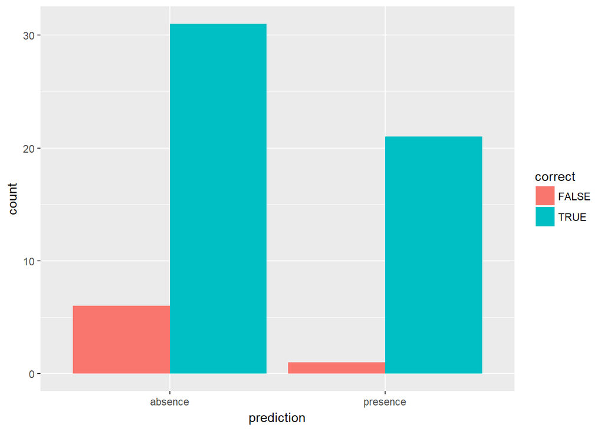

```r
# plot the predict and actural value
rf_results <- data.frame(actual = test_data2$status,
                      predict(model_rf, test_data2, type = "prob"))
rf_results$prediction <- ifelse(rf_results$presence > 0.5, "presence",
                             ifelse(rf_results$absence > 0.5,"absence", NA))
rf_results$correct <- ifelse(rf_results$actual == rf_results$prediction, TRUE, FALSE)

ggplot(rf_results, aes(x = prediction, fill = correct))+
  geom_bar(position = "dodge")
```

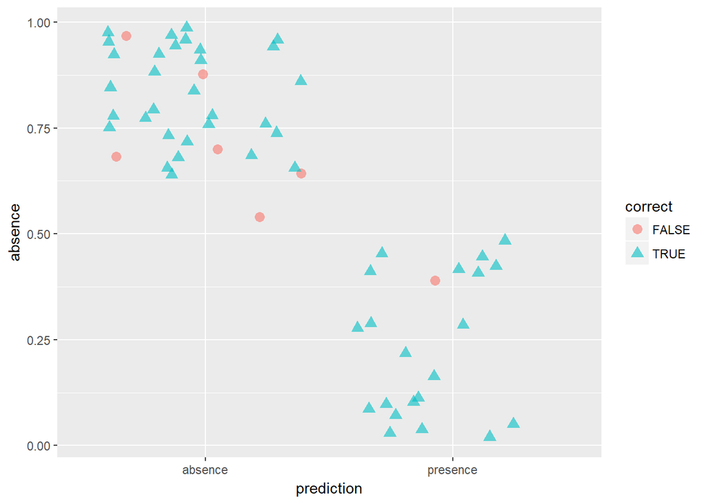

```r
ggplot(rf_results, aes(x = prediction, y = absence, color = correct , shape = correct)) +
  geom_jitter(size = 3, alpha = 0.6)
```

```r
## feature importance
rf_imp <- model_rf$finalModel$importance
rf_imp[order(rf_imp, decreasing = TRUE),]
```

```
##        ca   oldpeak        cp      thal   thalach     exang       sex
## 17.208674 12.423876 11.443686 11.188140 10.203633 10.192419  7.409750
##       age  trestbps     slope   restecg      chol       fbs
##  7.393803  7.384466  6.093551  6.031863  5.885215  4.763596
```

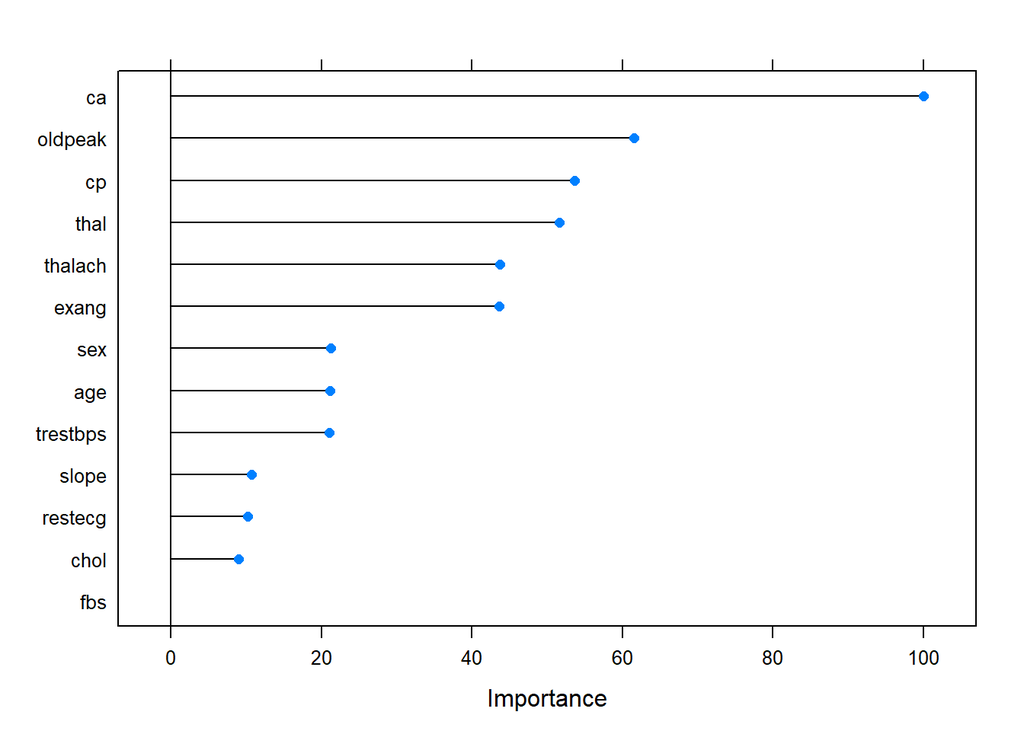

```r
# estimate variable importance
rf_importance <- varImp(model_rf, scale = TRUE)
plot(rf_importance)
```

#### /Extreme gradient boosting Tree/

- Packages used: **xgboost** (For the model), **caret**(For rf model and *ConfusionMatrix()* function), **ggplot2** (powerful plotting package)

Extreme gradient boosting (XGBoost) is a faster and improved implementation of gradient boosting for supervised learning. “XGBoost uses a more regularized model formalization to control over-fitting, which gives it better performance.” Tianqi Chen, developer of xgboost. XGBoost is a tree ensemble model, which means the sum of predictions from a set of classification and regression trees (CART). In that, XGBoost is similar to Random Forests but it uses a different approach to model training. Can be used for classification and regression tasks. In this model,we also used ROSE to deal with the imbalanced class. The accuracy of the model (model_xgb) is **0.8136**, and we evaluate the performance of the model by ConfusionMatrix, histogram plot and scatter plot. Feature importance is also shown as a plot. *ca*, *oldpeak*, *thalach* and *thal* have higher significance to this model.

```r
set.seed(142)
library(xgboost)
model_xgb <- caret::train(status ~ .,
                          data = train_data2,
                          method = "xgbTree",

                          trControl = trainControl(method = "repeatedcv",
                                                   number = 10,
                                                   repeats = 10,
                                                   savePredictions = TRUE,
                                                   #verboseIter = FALSE,
                                                   sampling = "rose"))
model_xgb
```

```
## eXtreme Gradient Boosting
##
## 244 samples
##  13 predictor
##   2 classes: 'absence', 'presence'
##
## No pre-processing
## Resampling: Cross-Validated (10 fold, repeated 10 times)
## Summary of sample sizes: 219, 219, 220, 220, 220, 220, ...
## Addtional sampling using ROSE
##
## Resampling results across tuning parameters:
##
##   eta  max_depth  colsample_bytree  subsample  nrounds  Accuracy
##   0.3  1          0.6               0.50        50      0.8225192
##   0.3  1          0.6               0.50       100      0.8151192
##   0.3  1          0.6               0.50       150      0.8135000
##   0.3  1          0.6               0.75        50      0.8168487
##   0.3  1          0.6               0.75       100      0.8139821
##   0.3  1          0.6               0.75       150      0.8139192
##   0.3  1          0.6               1.00        50      0.8128974
##   0.3  1          0.6               1.00       100      0.8123833
##   0.3  1          0.6               1.00       150      0.8086833
##   0.3  1          0.8               0.50        50      0.8196269
##   0.3  1          0.8               0.50       100      0.8102115
##   0.3  1          0.8               0.50       150      0.8126756
##   0.3  1          0.8               0.75        50      0.8058808
##   0.3  1          0.8               0.75       100      0.8039282
##   0.3  1          0.8               0.75       150      0.8071141
##   0.3  1          0.8               1.00        50      0.8119321
##   0.3  1          0.8               1.00       100      0.8094141
##   0.3  1          0.8               1.00       150      0.8101179
##   0.3  2          0.6               0.50        50      0.8034269
##   0.3  2          0.6               0.50       100      0.7992333
##   0.3  2          0.6               0.50       150      0.7980654
##   0.3  2          0.6               0.75        50      0.8096769
##   0.3  2          0.6               0.75       100      0.8169462
##   0.3  2          0.6               0.75       150      0.8112769
##   0.3  2          0.6               1.00        50      0.8103667
##   0.3  2          0.6               1.00       100      0.8116321
```

[output cut: 184 more lines]

```
##   0.6078812
##   0.6191766
##   0.6159796
##   0.6160562
##   0.6101066
##   0.6093131
##   0.6085136
##
## Tuning parameter 'gamma' was held constant at a value of 0
##
## Tuning parameter 'min_child_weight' was held constant at a value of 1
## Accuracy was used to select the optimal model using the largest value.
## The final values used for the model were nrounds = 50, max_depth = 1,
##  eta = 0.4, gamma = 0, colsample_bytree = 0.8, min_child_weight = 1
##  and subsample = 0.5.
```

```r
# testing data validation
xgb_pred <- predict(model_xgb, test_data2)
confusionMatrix(xgb_pred, test_data2$status, positive = "presence")
```

```
## Confusion Matrix and Statistics
##
##           Reference
## Prediction absence presence
##   absence       29        8
##   presence       3       19
##
##                Accuracy : 0.8136
##                  95% CI : (0.6909, 0.9031)
##     No Information Rate : 0.5424
##     P-Value [Acc > NIR] : 1.224e-05
##
##                   Kappa : 0.6189
##  Mcnemar's Test P-Value : 0.2278
##
##             Sensitivity : 0.7037
##             Specificity : 0.9062
##          Pos Pred Value : 0.8636
##          Neg Pred Value : 0.7838
##              Prevalence : 0.4576
##          Detection Rate : 0.3220
##    Detection Prevalence : 0.3729
##       Balanced Accuracy : 0.8050
##
##        'Positive' Class : presence
##
```

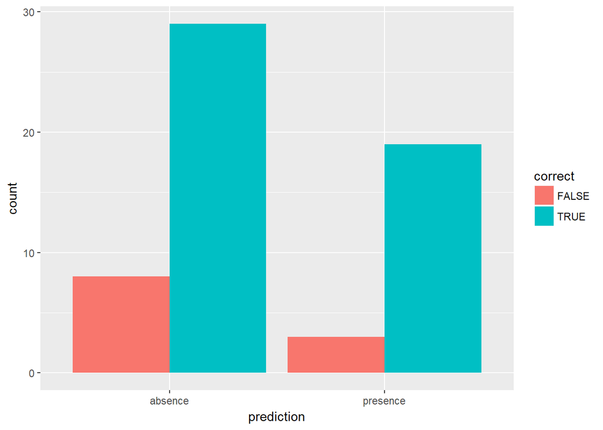

```r
# plot the predict and actural value
xgb_results <- data.frame(actual = test_data2$status,
                      predict(model_xgb, test_data2, type = "prob"))

xgb_results$prediction <- ifelse(xgb_results$presence> 0.5, "presence",
                             ifelse(xgb_results$absence > 0.5, "absence", NA))

xgb_results$correct <- ifelse(xgb_results$actual == xgb_results$prediction, TRUE, FALSE)

ggplot(xgb_results, aes(x = prediction, fill = correct)) +
  geom_bar(position = "dodge")
```

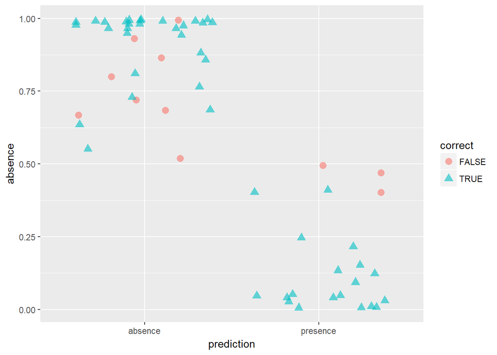

```r
ggplot(xgb_results, aes(x = prediction, y = absence, color = correct, shape = correct)) +
  geom_jitter(size = 3, alpha = 0.6)
```

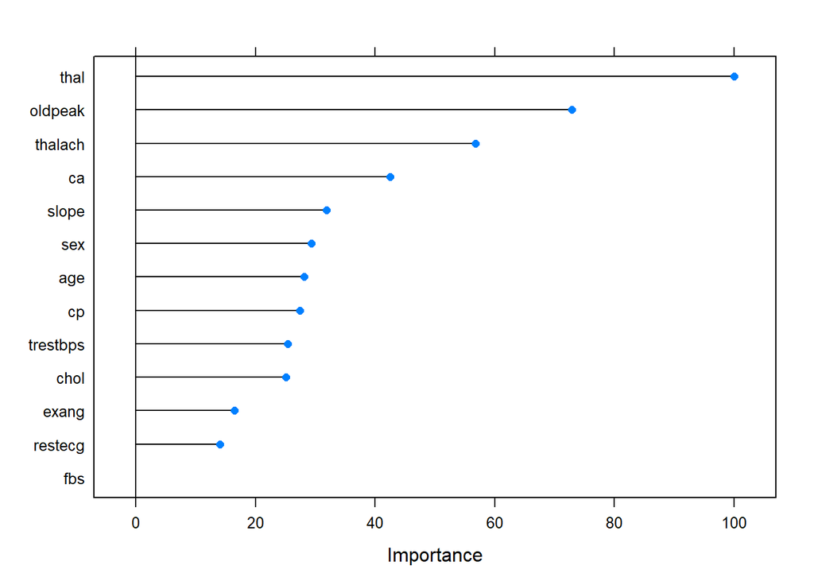

```r
## Feature Importance
xgb_importance <- varImp(model_xgb, scale = TRUE)
plot(xgb_importance)
```

### Models Evaluation

- Packages used: **pROC** (For ROC curve)

Receiver Operating Characteristic curve (ROC curve) is used to provide tools to select possibly optimal models and to discard suboptimal ones, which is a direct and natural way to cost/benefit analysis of diagnostic decision making. In other words, we are not only looking at the mod el accuracy, but also looking at the pattern generated by the true positive rate (sensitivity) and false positive rate (1-specificity) of the model. For easier comparision between models, we also calculated the area under curve (auc) for each models.The closer the auc equals to 1; the better the model is. In the result, **Random Forest** has the highest auc and accuarcy.

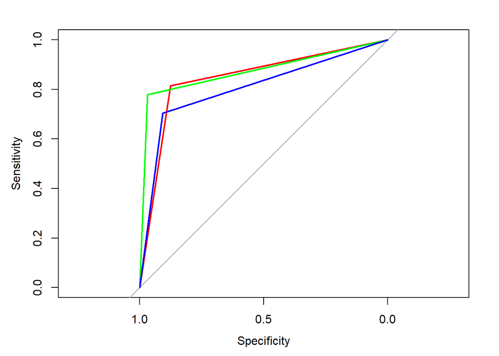

```r
library(pROC)
decision_roc <- roc(as.numeric(test_data2$status), as.numeric(decision_pred))
rf_roc <- roc(as.numeric(test_data2$status), as.numeric(model_rf_pred))
xgb_roc <- roc(as.numeric(test_data2$status), as.numeric(xgb_pred))

plot(decision_roc, col="red") # Red: Desicion Tree
lines(rf_roc, col="green") # Green: Random Forest
lines(xgb_roc, col= "blue") # Blue: Extreme gradient boosting Tree
```

```r
data.frame(model=c("decision tree", "random forest", "Extreme gradient boosting trees"), auc = c(auc(decision_roc), auc(rf_roc), auc(xgb_roc)))
```

```
##                             model       auc
## 1                   decision tree 0.8449074
## 2                   random forest 0.8732639
## 3 Extreme gradient boosting trees 0.8049769
```

### Feature Selection

We could find that the importance of features are slightly different among the three models above.But they can still tell us that some of them are more important that other features.Considering high correlation coefficient of **“slope”**,basicly the most important features are *ca*, *oldpeak*, *cp* and *thal*. We could also use an automatic way to choose features, which is Recursive Feature Elimination. RFE uses a Random Forest algorithm to test combinations of features and rate each with an accuracy score. The combination with the highest score is usually preferential.And this method leaves us three features,*cp*,*ca*,and *thal*.

```r
sum_decision_fit$variable.importance
```

```
##         cp       thal      exang    thalach    oldpeak         ca
## 39.4916971 27.1179228 18.4422896 16.5079020 12.2168981 11.4095093
##      slope        age        sex   trestbps       chol
##  6.5597781  4.9823718  3.6001389  1.2275073  0.9245292
```

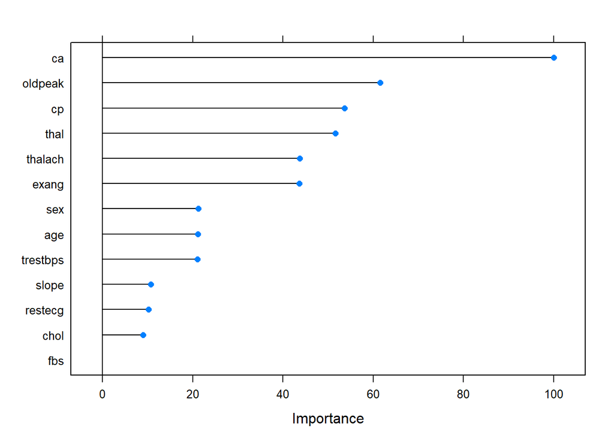

```r
plot(rf_importance)
```

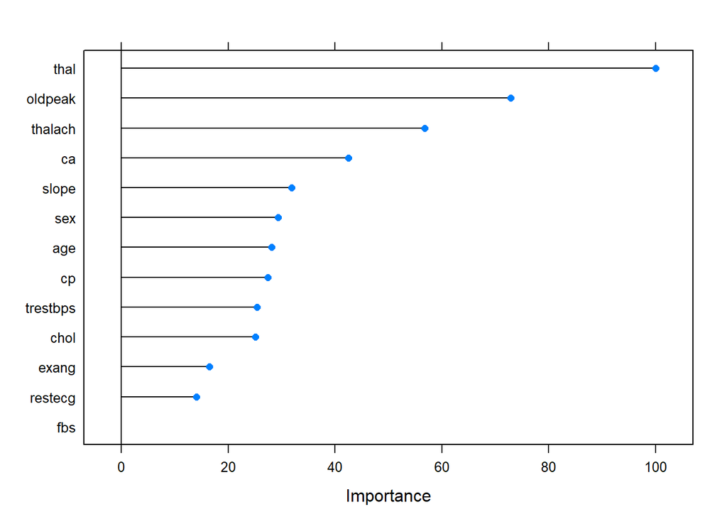

```r
plot(xgb_importance)
```

```r
## Recursive Feature Elimination

set.seed(7)
results_rfe <- rfe(x = train_data2[,-14],
                   y = train_data2$status,
                   sizes = c(1:13),
                   rfeControl = rfeControl(functions = rfFuncs,
                                           method = "cv", number = 10)
                   )
## chosen features
predictors(results_rfe)
```

```
## [1] "cp"   "ca"   "thal"
```

```r
train_data2_rfe <- train_data2[,c(which(colnames(train_data2) %in% predictors(results_rfe)),14)]
test_data2_rfe <- test_data2[,c(which(colnames(test_data2) %in% predictors(results_rfe)),14)]
head(train_data2_rfe)
```

```
##           cp         ca       thal   status
## 1 -2.2480557 -0.7099569  0.6514824  absence
## 3  0.8765355  1.4305102  1.1668850 presence
## 4 -0.1649949 -0.7099569 -0.8947252  absence
## 5 -1.2065253 -0.7099569 -0.8947252  absence
## 6 -1.2065253 -0.7099569 -0.8947252  absence
## 7  0.8765355  1.4305102 -0.8947252 presence
```

### Model Improvement

Then we have the data with eliminated features,and we can do grid search with *caret* and **Random Forest** again.But the result turns out no better than the original one. The ROC Curve shows that the performance of origianl data is better.

```r
## Grid search with caret
set.seed(42)
model_rf_tune_auto <- caret::train(status ~ .,
                         data = train_data2_rfe,
                         method = "rf",
                        # preProcess = c("scale", "center"),
                         trControl = trainControl(method = "repeatedcv",
                                                  number = 10,
                                                  repeats = 10,
                                                  savePredictions = TRUE,
                                                  verboseIter = FALSE,
                                                  search = "random",
                                                  sampling = "rose"),
                         tuneLength = 15)

model_rf_tune_auto
```

```
## Random Forest
##
## 244 samples
##   3 predictor
##   2 classes: 'absence', 'presence'
##
## No pre-processing
## Resampling: Cross-Validated (10 fold, repeated 10 times)
## Summary of sample sizes: 220, 220, 220, 219, 220, 220, ...
## Addtional sampling using ROSE
##
## Resampling results across tuning parameters:
##
##   mtry  Accuracy   Kappa
##   1     0.8162256  0.6292162
##   2     0.7961474  0.5874278
##   3     0.7921538  0.5780548
##
## Accuracy was used to select the optimal model using the largest value.
## The final value used for the model was mtry = 1.
```

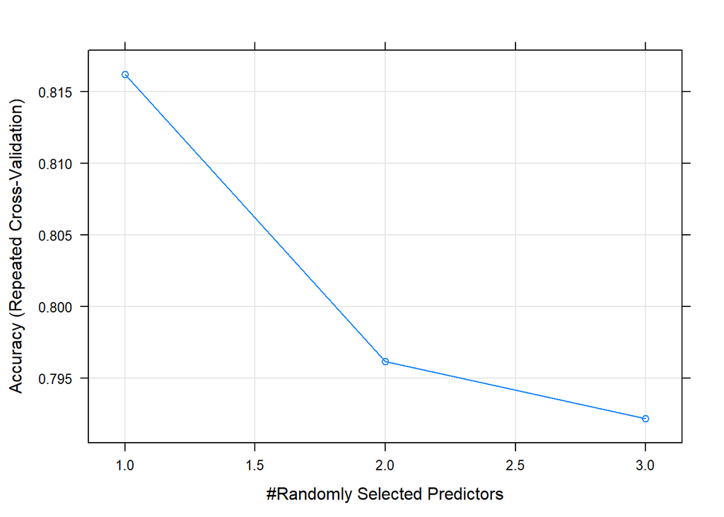

```r
plot(model_rf_tune_auto)
```

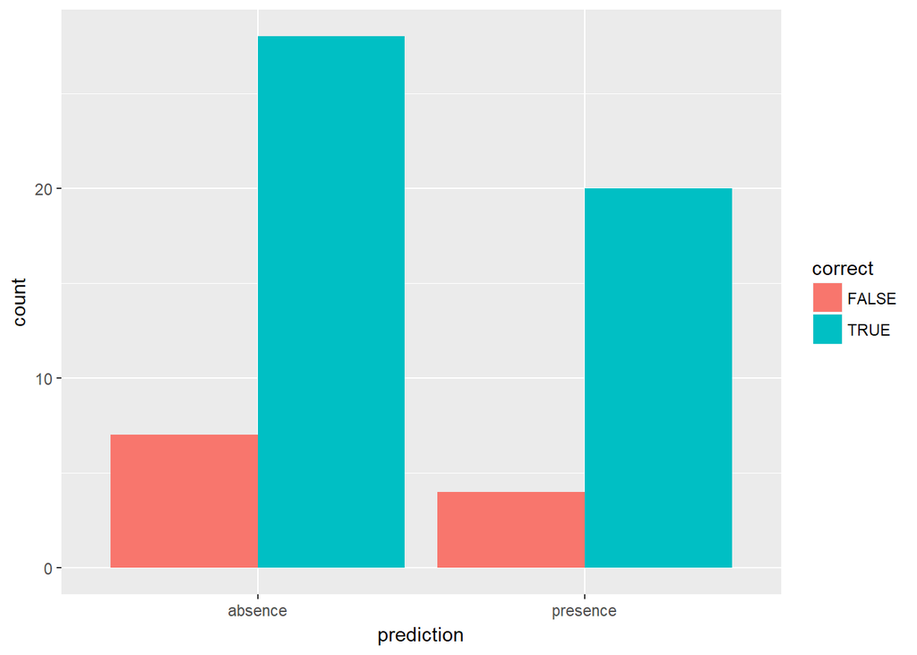

```r
results <- data.frame(actual = test_data2_rfe$status,
                      predict(model_rf_tune_auto, test_data2_rfe, type = "prob"))

  results$prediction <- ifelse(results$presence> 0.5, "presence",
                             ifelse(results$absence > 0.5, "absence", NA))

  results$correct <- ifelse(results$actual == results$prediction, TRUE, FALSE)

ggplot(results, aes(x = prediction, fill = correct)) +
  geom_bar(position = "dodge")
```

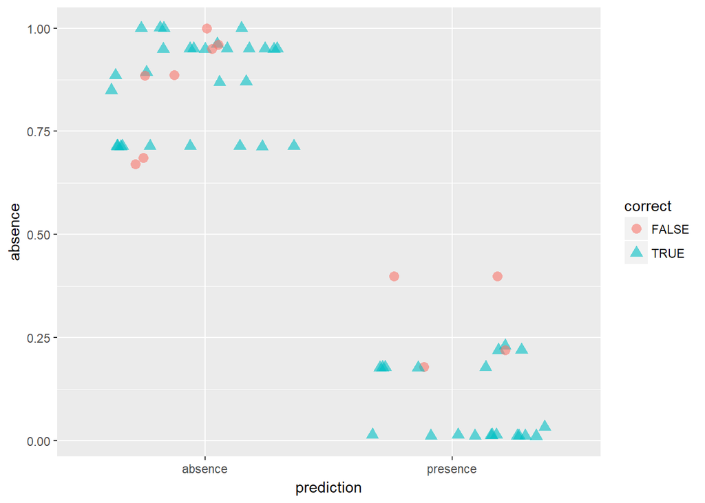

```r
ggplot(results, aes(x = prediction, y = absence, color = correct, shape = correct)) +
  geom_jitter(size = 3, alpha = 0.6)
```

```r
## predicting test data
rfe_pred_2 <- predict(model_rf_tune_auto, test_data2_rfe)
confusionMatrix(rfe_pred_2,test_data2_rfe$status,positive = "presence")
```

```
## Confusion Matrix and Statistics
##
##           Reference
## Prediction absence presence
##   absence       28        7
##   presence       4       20
##
##                Accuracy : 0.8136
##                  95% CI : (0.6909, 0.9031)
##     No Information Rate : 0.5424
##     P-Value [Acc > NIR] : 1.224e-05
##
##                   Kappa : 0.6211
##  Mcnemar's Test P-Value : 0.5465
##
##             Sensitivity : 0.7407
##             Specificity : 0.8750
##          Pos Pred Value : 0.8333
##          Neg Pred Value : 0.8000
##              Prevalence : 0.4576
##          Detection Rate : 0.3390
##    Detection Prevalence : 0.4068
##       Balanced Accuracy : 0.8079
##
##        'Positive' Class : presence
##
```

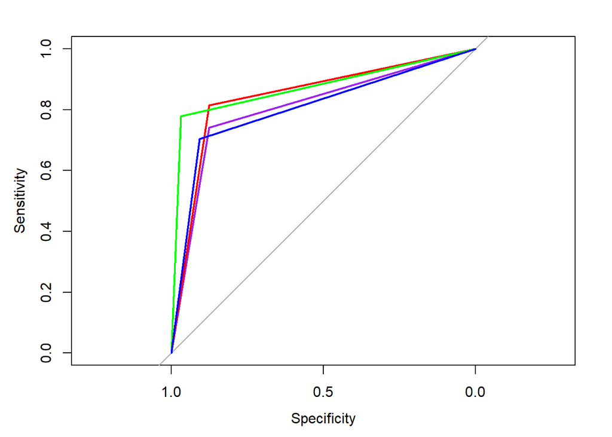

```r
## ROC Curve and AUC comparation
ref_roc <- roc(as.numeric(test_data2_rfe$status), as.numeric(rfe_pred_2))

plot(ref_roc, col="purple")
lines(decision_roc, col="red")
lines(rf_roc, col="green")
lines(xgb_roc, col= "blue")
```

### Conclusion

There is no âONE-SIZE-FITS-ALLâ approach to ML. It is always good to know your data well before modeling like how to dealing with missing data, imbalance data, and different variable types. In so doing, we will have an idea of finding a way to do the pre-processing and feature selection in order to see if we can optimize the models. Testing different models and evaluating the effectiveness between them are also improtant when developing a meaningful model. In this dataset, although we need more tuning with the feature selection and other parameters, at this point, the random forest model has the best performance within the discussed 4 models.